# Comprehensive Resistome Analysis

- Show All Code
- Hide All Code
- View Source

KPC-31 Carbapenemase-Producing Enterobacterales

Author

Russell Lewis

Published

December 27, 2025

# Executive Summary

This report presents a comprehensive analysis of 42 bacterial isolates from the KPC-31 resistome project. The dataset includes detailed characterization of carbapenemase-producing *Klebsiella pneumoniae* and *Escherichia coli* isolates, with emphasis on:

- **Species and molecular typing** (sequence types, capsular types)
- **Antimicrobial resistance phenotypes** (MIC values for 26 antibiotics)
- **Resistance genotypes** (36 resistance genes identified)
- **Plasmid incompatibility groups** (15 Inc groups detected)
- **Horizontal gene transfer patterns**

## Key Findings

**ImportantCritical Discovery: Universal blaKPC-31 Carriage**

**ALL 42 isolates (100%) carry the blaKPC-31 carbapenemase gene**, indicating this is a KPC-31-specific collection or outbreak. This variant is responsible for the observed carbapenem resistance and variable ceftazidime-avibactam (CAZ-AVI) resistance across isolates.

# 1 Dataset Overview

## 1.1 Data Structure

```
Dataset Dimensions:
```

```
• Total isolates: 42
```

```
• Total variables: 155
```

```
• Antibiotics tested (MIC): ~26
```

```
• Resistance genes analyzed: 36
```

```
• Plasmid Inc groups detected: 15
```

## 1.2 Data Completeness

Table 1: Data completeness for key metadata variables

| Variable | Total | Complete | Missing | % Complete |
| --- | --- | --- | --- | --- |
| ID | 42 | 42 | 0 | 100.0 |
| Species | 42 | 42 | 0 | 100.0 |
| Clinical Source | 42 | 32 | 10 | 76.2 |
| Sequence Type (ST) | 42 | 32 | 10 | 76.2 |
| Capsular Type (KL) | 42 | 10 | 32 | 23.8 |
| Wzi Type | 42 | 9 | 33 | 21.4 |

# 2 Bacterial Characterization

## 2.1 Species Distribution

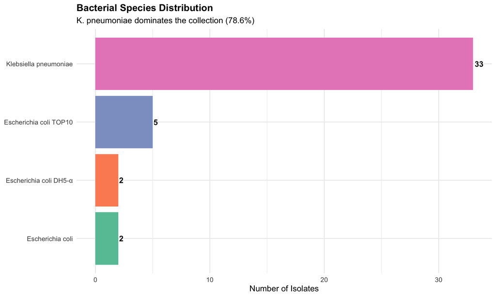

Figure 1: Distribution of bacterial species in the collection

**NoteSpecies Composition**

- **Klebsiella pneumoniae**: 33/42 isolates (78.6%)
- **Escherichia coli** variants: 9/42 isolates (21.4%)
  - *E. coli* TOP10: 5 isolates (lab strain)
  - *E. coli* DH5-α: 2 isolates (lab strain)
  - *E. coli*: 2 isolates (clinical)

## 2.2 Sequence Types (MLST)

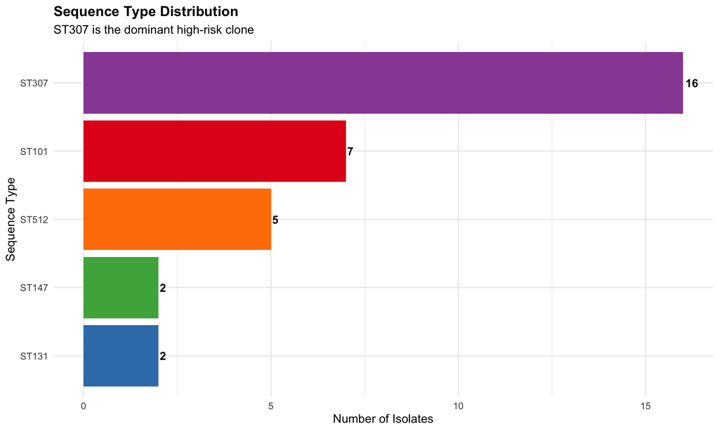

Figure 2: Distribution of sequence types among typed isolates

Table 2: Summary of sequence types and their clinical significance

| ST | n | Percentage | Species | Clinical.Significance |
| --- | --- | --- | --- | --- |
| ST307 | 16 | 50.0 | K. pneumoniae | Global high-risk clone |
| ST101 | 7 | 21.9 | K. pneumoniae | MDR clone |
| ST512 | 5 | 15.6 | K. pneumoniae | Emerging high-risk clone |
| ST131 | 2 | 6.3 | E. coli | Global E. coli pandemic clone |
| ST147 | 2 | 6.3 | K. pneumoniae | MDR K. pneumoniae clone |

## 2.3 Clinical Sources

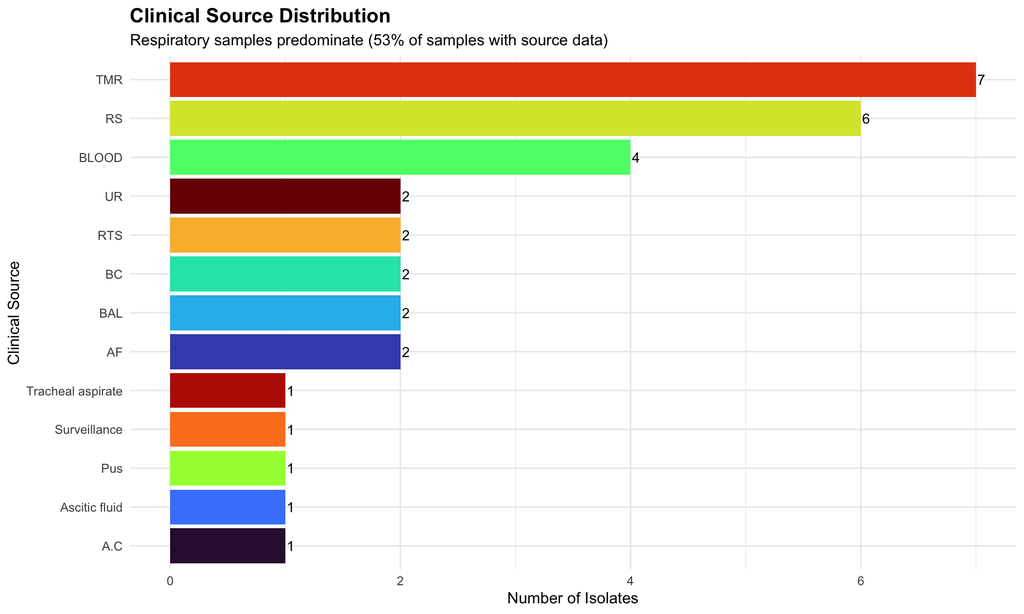

Figure 3: Distribution of clinical specimen types

## 2.4 Capsular Types (KL)

**ImportantPerfect KL-ST Association**

Each capsular type is **exclusively associated with one sequence type**, suggesting stable clonal lineages:

- **KL107 ↔︎ ST512** (n=4)
- **KL102 ↔︎ ST307** (n=2)
- **KL17 ↔︎ ST101** (n=2)
- **KL64 ↔︎ ST147** (n=2)

Only 23.8% (10/42) of isolates have capsular typing data, but the perfect association is striking.

# 3 Antimicrobial Resistance Phenotypes

## 3.1 Ceftazidime-Avibactam (CAZ-AVI) Resistance

[figure not shown]

Figure 4: Distribution of CAZ-AVI MIC values

## 3.2 CAZ-AVI Resistance by Sequence Type

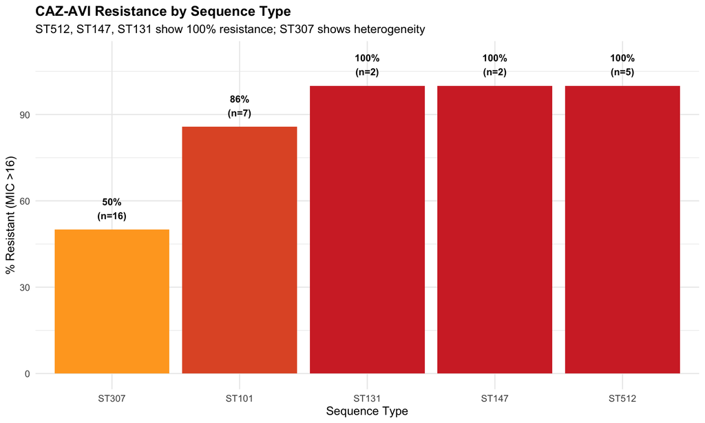

Figure 5: CAZ-AVI resistance stratified by sequence type

**WarningST307 Heterogeneous Resistance**

ST307 shows a **50/50 split** between intermediate and resistant isolates, suggesting:

- Evolving resistance mechanisms within this clone
- Potential for further resistance development
- Need for careful monitoring

## 3.3 Multi-Antibiotic Resistance Heatmap

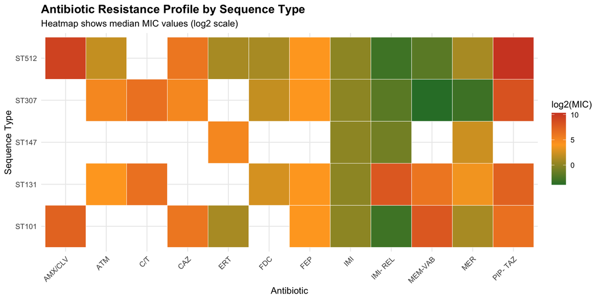

Figure 6: Median MIC values across antibiotics by sequence type

# 4 Resistance Genotypes

## 4.1 blaKPC-31: The Universal Carbapenemase

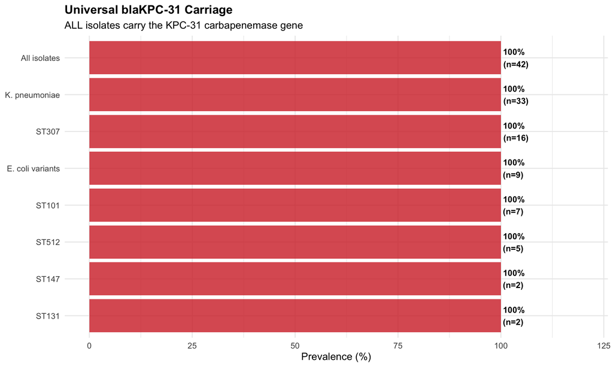

Figure 7: blaKPC-31 prevalence across species and sequence types

**ImportantUniversal KPC-31 Carriage**

**100% of isolates** (42/42) carry blaKPC-31, including:

- All *K. pneumoniae* isolates
- All *E. coli* isolates (including lab strains)
- All sequence types
- Both clinical and environmental isolates

This indicates a **KPC-31-specific collection or outbreak**.

## 4.2 Resistance Gene Profiles by Clone

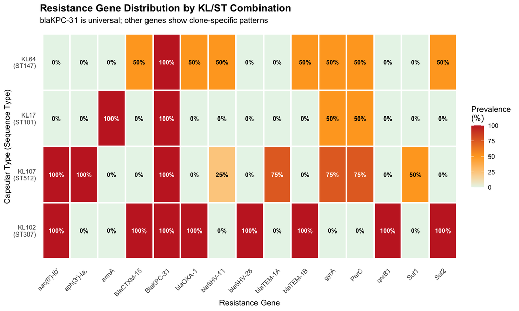

Figure 8: Resistance gene profiles for isolates with capsular typing

Table 3: Summary of resistance genes by KL/ST combination

| Clone | Total.Genes | Beta.lactamases | Key.Features |
| --- | --- | --- | --- |
| KL64 (ST147) | 15 | KPC-31, CTX-M-15, TEM-1B, SHV-11, OXA-1 | Most genes; fosfomycin resistance |
| KL102 (ST307) | 13 | KPC-31, CTX-M-15, TEM-1B, SHV-28, OXA-1 | qnrB1 quinolone resistance |
| KL107 (ST512) | 12 | KPC-31, TEM-1A, SHV-158 | IncX3 plasmid-associated |
| KL17 (ST101) | 5 | KPC-31, SHV-1 | armA (pan-AMG resistance) |

**NoteNotable Findings**

- **KL64 (ST147)**: Highest gene count (15), includes fosA (fosfomycin resistance)
- **KL17 (ST101)**: Lowest gene count (5), but includes armA conferring pan-aminoglycoside resistance
- **KL102 (ST307)**: Carries qnrB1 providing quinolone resistance
- **KL107 (ST512)**: Associated with IncX3 plasmid

# 5 Capsular Type-Resistance Associations

## 5.1 KL-ST Perfect Association

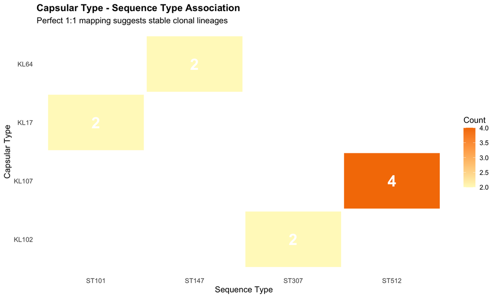

Figure 9: Perfect 1:1 association between capsular types and sequence types

## 5.2 CAZ-AVI Resistance by Capsular Type

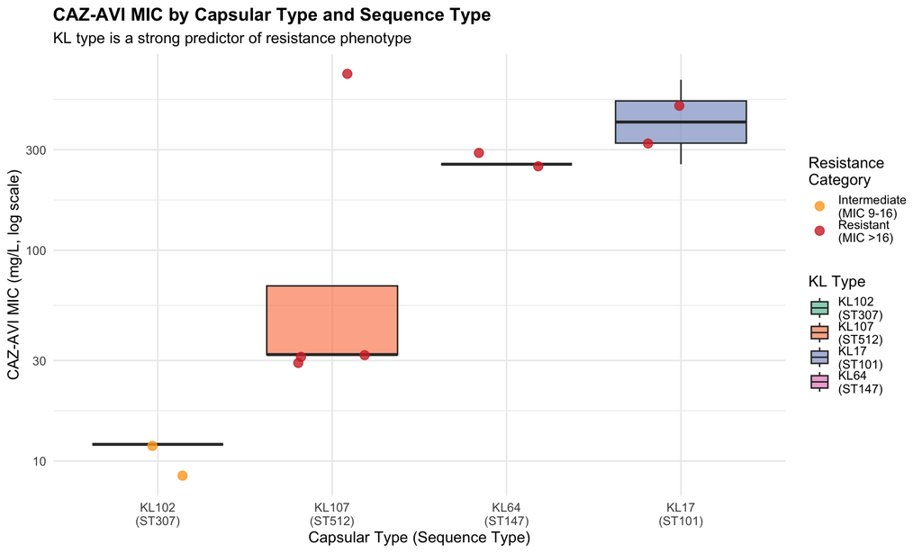

Figure 10: CAZ-AVI resistance profiles differ dramatically by capsular type

Table 4: CAZ-AVI resistance profiles by capsular type

[output not shown]

# 6 Plasmid Incompatibility Groups

## 6.1 Inc Group Distribution

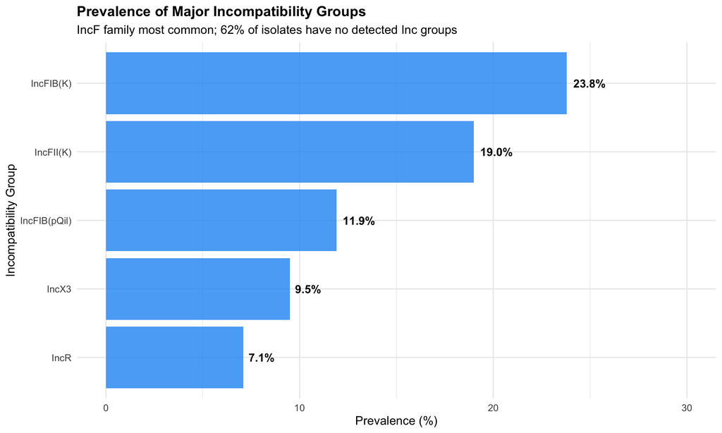

Figure 11: Prevalence of major incompatibility groups

## 6.2 Inc Groups by Clone

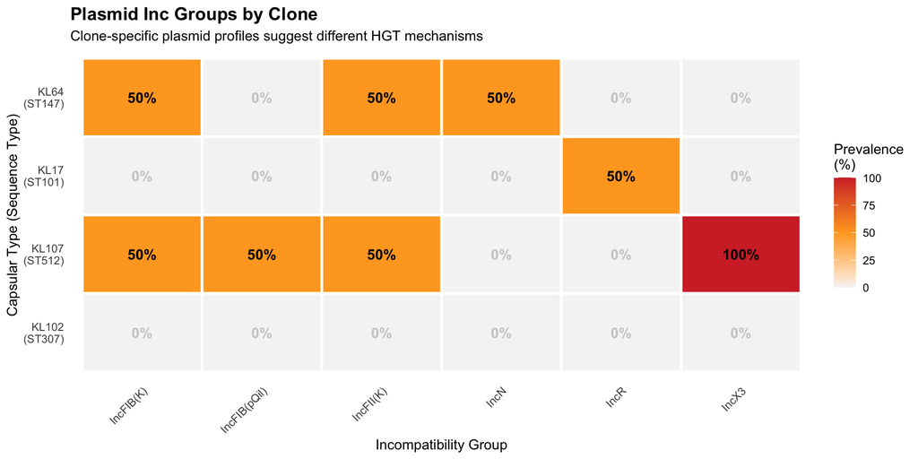

Figure 12: Incompatibility group distribution by KL/ST combination

**ImportantClone-Specific Plasmid Profiles**

- **KL107 (ST512)**: IncX3 (100%) - fixed, likely carries blaKPC-31
- **KL17 (ST101)**: IncR (50%) - may carry armA gene
- **KL64 (ST147)**: IncF family (50%) - high HGT potential
- **KL102 (ST307)**: NO Inc groups detected - chromosomal integration?

## 6.3 Horizontal Gene Transfer Evidence

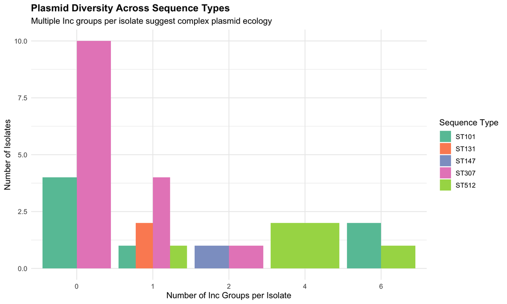

Figure 13: Plasmid diversity indicates horizontal gene transfer potential

Table 5: Evidence for horizontal gene transfer by Inc group

| Inc.Group | Distribution | HGT.Evidence | Significance |
| --- | --- | --- | --- |
| IncFIB(K) / IncFII(K) | 4 different STs | ★★★★★ High | Active dissemination within K. pneumoniae |
| IncX3 | ST512 only | ★☆☆☆☆ None | Clone-specific, stable, not spreading |
| IncR | Primarily ST101 | ★★☆☆☆ Limited | May carry armA, limited to one clone |
| IncN | Rare, isolated | ★★★☆☆ Moderate | Recent acquisition, broad host range potential |

# 7 Integrated Analysis

## 7.1 Relationships Between Plasmids, Genes, and Resistance

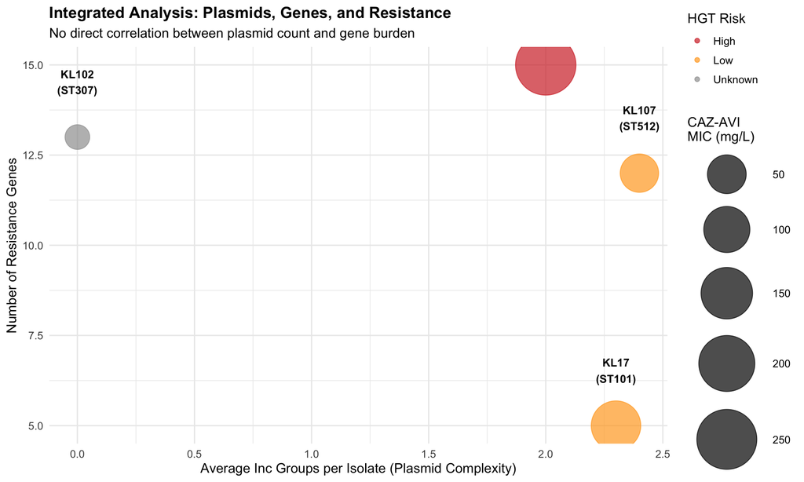

Figure 14: Integrated view of plasmid complexity, gene burden, and resistance levels

## 7.2 Summary Table: Clone Characteristics

Table 6: Comprehensive summary of clone characteristics

[output not shown]

# 8 Clinical Implications

## 8.1 Treatment Challenges

**WarningExtremely Limited Treatment Options**

### 8.1.1 Potential Treatment Strategies

Table 7: Potential treatment options by clone type

| Clone | First.Line | Second.Line | Last.Resort | Notes |
| --- | --- | --- | --- | --- |
| KL107 (ST512) | Cefiderocol | Carbapenem + AVI | Colistin | IncX3-stable resistance |
| KL17 (ST101) | Cefiderocol | Plazomicin (not armA) | Colistin | armA limits aminoglycosides |
| KL64 (ST147) | Combination therapy | Carbapenem + fosfomycin | Colistin | High gene burden, test all options |
| KL102 (ST307) | Carbapenems | CAZ-AVI | Colistin | Best prognosis of 4 clones |

## 8.2 Infection Control Priorities

### 8.2.1 High-Risk Clones for Isolation

1. **ST512 (KL107)**: IncX3 plasmid stable but high resistance
2. **ST101 (KL17)**: armA-mediated pan-aminoglycoside resistance
3. **ST147 (KL64)**: IncF plasmids with high HGT potential

### 8.2.2 Surveillance Recommendations

[output not shown]

# 9 Conclusions

## 9.1 Key Findings Summary

1. **Universal blaKPC-31 carriage** (100%, 42/42) defines this collection
2. **ST307 is dominant** (50% of typed isolates) but shows heterogeneous resistance
3. **Perfect KL-ST associations** indicate stable clonal lineages
4. **IncF plasmids are disseminating** across multiple K. pneumoniae clones
5. **Clone-specific resistance mechanisms**:
   - ST512: IncX3-based (stable, not spreading)
   - ST101: IncR-based (armA-mediated pan-AMG resistance)
   - ST147: IncF-based (high HGT risk)
   - ST307: Unknown mechanism (requires investigation)

## 9.2 Critical Questions for Further Investigation

**TipRecommended Next Steps**

1. **Whole plasmid sequencing**: Map complete genetic context of resistance genes
2. **ST307 mechanism**: Investigate chromosomal vs cryptic plasmid integration
3. **IncX3 plasmid characterization**: Complete sequence of ST512 blaKPC-31-bearing plasmid
4. **Temporal analysis**: If collection dates available, track resistance evolution
5. **Epidemiological links**: Investigate patient/ward connections for transmission chains
6. **Functional studies**: Test plasmid transferability and fitness costs

## 9.3 Public Health Implications

**ImportantOutbreak Potential**

This collection represents either:

- A **KPC-31-specific outbreak** with multiple introductions
- A **surveillance collection** of endemic KPC-31 strains
- **Clonal expansion** of resistant lineages with horizontal gene transfer

The presence of **high-risk global clones** (ST307, ST512, ST101, ST131, ST147) combined with **active plasmid dissemination** (IncF family) represents a significant public health concern requiring immediate infection control measures.

# 10 Methods

## 10.1 Data Source

- Dataset: Progetto 1 (KPC-31) versione 2.xlsx
- 42 bacterial isolates
- 155 variables including:
  - Bacterial identification (species, MLST, capsular typing)
  - Antimicrobial susceptibility testing (MIC for ~26 antibiotics)
  - Resistance gene detection (36 genes)
  - Plasmid replicon typing (15 incompatibility groups)

## 10.2 Analytical Approach

All analyses were performed using R version 4.5.1 with the following packages:

- `tidyverse` for data manipulation and visualization
- `readxl` for Excel file import
- `ggplot2` for graphics
- `knitr` and `kableExtra` for tables

### 10.2.1 Resistance Categorization

- **CAZ-AVI Susceptible**: MIC ≤8 mg/L
- **CAZ-AVI Intermediate**: MIC 9-16 mg/L
- **CAZ-AVI Resistant**: MIC >16 mg/L

### 10.2.2 Statistical Notes

- Percentages calculated on non-missing values
- Median MIC used for heatmaps to reduce outlier effects
- Log2 transformation applied for MIC visualization

# 11 Appendix

## 11.1 Complete Resistance Gene List

Table 8: Complete list of resistance genes detected in the dataset

| Category | Gene | Mechanism |
| --- | --- | --- |
| **Beta-lactamases** |  |  |
| Beta-lactamases | BlaKPC-31 | Carbapenemase (KPC) |
| Beta-lactamases | BlaCTXM-15 | ESBL (CTX-M) |
| Beta-lactamases | blaTEM-1A | Beta-lactamase (TEM) |
| Beta-lactamases | blaTEM-1B | Beta-lactamase (TEM) |
| Beta-lactamases | blaSHV-1 | Beta-lactamase (SHV) |
| Beta-lactamases | blaSHV-11 | Beta-lactamase (SHV) |
| Beta-lactamases | blaSHV-28 | Beta-lactamase (SHV) |
| Beta-lactamases | BlaSHV-106 | Beta-lactamase (SHV) |
| Beta-lactamases | BlaSHV-158 | Beta-lactamase (SHV) |
| Beta-lactamases | blaOXA-1 | Beta-lactamase (OXA) |
| Beta-lactamases | bla OXA-9 | Beta-lactamase (OXA) |
| **Aminoglycosides** |  |  |
| Aminoglycosides | aadA | Aminoglycoside acetyltransferase |
| Aminoglycosides | aaaA2 | Aminoglycoside resistance |
| Aminoglycosides | aac(6′)-Ib' | Aminoglycoside acetyltransferase |
| Aminoglycosides | aac(6´)-Ib-cr | AMG + FQ resistance |
| Aminoglycosides | ant(2′')-Ia | Aminoglycoside nucleotidyltransferase |
| Aminoglycosides | aac(3)-IIa | Aminoglycoside acetyltransferase |
| Aminoglycosides | armA | 16S rRNA methylase (pan-AMG) |
| Aminoglycosides | aph(3')-Ia | Aminoglycoside phosphotransferase |
| **Quinolones** |  |  |
| Quinolones | ParC | DNA gyrase mutation |
| Quinolones | gyrA | DNA gyrase mutation |
| Quinolones | qnrB1 | Quinolone resistance |
| **Other Mechanisms** |  |  |
| Other | Sul1 | Sulfonamide resistance |
| Other | Sul2 | Sulfonamide resistance |
| Other | fosA | Fosfomycin resistance |

## 11.2 Abbreviations

- **AMG**: Aminoglycoside
- **CAZ-AVI**: Ceftazidime-avibactam
- **ESBL**: Extended-spectrum beta-lactamase
- **HGT**: Horizontal gene transfer
- **Inc**: Incompatibility
- **KL**: Capsular type (K locus)
- **MDR**: Multi-drug resistant
- **MIC**: Minimum inhibitory concentration
- **MLST**: Multi-locus sequence typing
- **ST**: Sequence type

**Report generated on:** April 15, 2026

**Analysis platform:** Positron 2025.12.2 with R 4.5.1